# TOD Assignment: Boston, Massachusetts

Anna Duan (worked with Bingchu Chen)

9/25/2020

# 1 Introduction

Boston, Massachusetts has one of the nations’s most developed public transportation systems, with the Massachusetts Bay Transportation Authority (MTBA) operating subway, trolley, bus, and boat services. In recent years, [MBTA](https://www.mbtarealty.com/transit-oriented-development/) has worked with developers and the city to develop more than 50 Transit Oriented Development (TOD) projects near its stations. These projects are expected to increase local land value, make the transit system more efficient, and make neighborhoods more desirable. However, given the current funding cuts in the public transportation sector due to the COVID-19 pandemic, we must critically assess previous projects to determine where best to allocate funds in the future. In this brief, we investigate whether, and where, TOD has increased neighborhood value and desirability in Boston. We then identify limitations and areas for future expansion.

```r
knitr::opts_chunk$set

############################LIBRARIES AND OPTIONS SETUP##############################
library(tidyverse)
library(tidycensus)
library(sf)
library(kableExtra)

options(scipen=999)
options(tigris_class = "sf")

##############################DEFINE MULTIPLERINGBUFFER##############################
multipleRingBuffer <- function(inputPolygon, maxDistance, interval)
{
  #create a list of distances that we'll iterate through to create each ring
  distances <- seq(0, maxDistance, interval)
  #we'll start with the second value in that list - the first is '0'
  distancesCounter <- 2
  #total number of rings we're going to create
  numberOfRings <- floor(maxDistance / interval)
  #a counter of number of rings
  numberOfRingsCounter <- 1
  #initialize an otuput data frame (that is not an sf)
  allRings <- data.frame()

  #while number of rings  counteris less than the specified nubmer of rings
  while (numberOfRingsCounter <= numberOfRings)
  {
    #if we're interested in a negative buffer and this is the first buffer
    #(ie. not distance = '0' in the distances list)
    if(distances[distancesCounter] < 0 & distancesCounter == 2)
    {
      #buffer the input by the first distance
      buffer1 <- st_buffer(inputPolygon, distances[distancesCounter])
      #different that buffer from the input polygon to get the first ring
      buffer1_ <- st_difference(inputPolygon, buffer1)
      #cast this sf as a polygon geometry type
      thisRing <- st_cast(buffer1_, "POLYGON")
      #take the last column which is 'geometry'
      thisRing <- as.data.frame(thisRing[,ncol(thisRing)])
      #add a new field, 'distance' so we know how far the distance is for a give ring
      thisRing$distance <- distances[distancesCounter]
    }

    #otherwise, if this is the second or more ring (and a negative buffer)
    else if(distances[distancesCounter] < 0 & distancesCounter > 2)
    {
      #buffer by a specific distance
      buffer1 <- st_buffer(inputPolygon, distances[distancesCounter])
      #create the next smallest buffer
      buffer2 <- st_buffer(inputPolygon, distances[distancesCounter-1])
      #This can then be used to difference out a buffer running from 660 to 1320
      #This works because differencing 1320ft by 660ft = a buffer between 660 & 1320.
      #bc the area after 660ft in buffer2 = NA.
      thisRing <- st_difference(buffer2,buffer1)
      #cast as apolygon
      thisRing <- st_cast(thisRing, "POLYGON")
      #get the last field
      thisRing <- as.data.frame(thisRing$geometry)
      #create the distance field
      thisRing$distance <- distances[distancesCounter]
    }

    #Otherwise, if its a positive buffer
    else
    {
      #Create a positive buffer
      buffer1 <- st_buffer(inputPolygon, distances[distancesCounter])
      #create a positive buffer that is one distance smaller. So if its the first buffer
      #distance, buffer1_ will = 0.
      buffer1_ <- st_buffer(inputPolygon, distances[distancesCounter-1])
      #difference the two buffers
      thisRing <- st_difference(buffer1,buffer1_)
      #cast as a polygon
      thisRing <- st_cast(thisRing, "POLYGON")
      #geometry column as a data frame
      thisRing <- as.data.frame(thisRing[,ncol(thisRing)])
      #add the distance
      thisRing$distance <- distances[distancesCounter]
    }

    #rbind this ring to the rest of the rings
    allRings <- rbind(allRings, thisRing)
    #iterate the distance counter
    distancesCounter <- distancesCounter + 1
    #iterate the number of rings counter
    numberOfRingsCounter <- numberOfRingsCounter + 1
  }
  #convert the allRings data frame to an sf data frame
  allRings <- st_as_sf(allRings)
}

################################PLOT/MAP FORMAT################################
mapTheme <- function(base_size = 12) {
  theme(
    text = element_text( color = "black"),
    plot.title = element_text(size = 12,colour = "black"),
    plot.subtitle=element_text(face="italic"),
    plot.caption=element_text(hjust=0),
    axis.ticks = element_blank(),
    panel.background = element_blank(),axis.title = element_blank(),
    axis.text = element_blank(),
    axis.title.x = element_blank(),
    axis.title.y = element_blank(),
    panel.grid.minor = element_blank(),
    panel.border = element_rect(colour = "black", fill=NA, size=2),
    strip.text.x = element_text(size = 10))
}
plotTheme <- function(base_size = 12) {
  theme(
    text = element_text( color = "black"),
    plot.title = element_text(size = 12,colour = "black"),
    plot.subtitle = element_text(face="italic"),
    plot.caption = element_text(hjust=0),
    axis.ticks = element_blank(),
    panel.background = element_blank(),
    panel.grid.major = element_line("grey80", size = 0.1),
    panel.grid.minor = element_blank(),
    panel.border = element_rect(colour = "black", fill=NA, size=2),
    strip.background = element_rect(fill = "grey80", color = "white"),
    strip.text = element_text(size=10),
    axis.title = element_text(size=10),
    axis.text = element_text(size=10),
    plot.background = element_blank(),
    legend.background = element_blank(),
    legend.title = element_text(colour = "black", face = "italic"),
    legend.text = element_text(colour = "black", face = "italic"),
    strip.text.x = element_text(size = 10)
  )
}
################################QUINTILE BREAKS################################
qBr <- function(df, variable, rnd) {
  if (missing(rnd)) {
    as.character(quantile(round(df[[variable]],0),
                          c(.01,.2,.4,.6,.8), na.rm=T))
  } else if (rnd == FALSE | rnd == F) {
    as.character(formatC(quantile(df[[variable]]), digits = 3),
                 c(.01,.2,.4,.6,.8), na.rm=T)
  }
}
q5 <- function(variable) {as.factor(ntile(variable, 5))}
# Palette
palette5 <- c("#daf9f5","#98dbd9","#5dafb6","#1d696b","#003233")


################################PULL ACS DATA################################
# Input API key
census_api_key("d9ebfd04caa0138647fbacd94c657cdecbf705e9", install = TRUE, overwrite = TRUE)
```

```r
# Variables: Median Rent, Median HH Income, Population, Bachelor's, No Vehicle (home owner, renter), Households (owner, renter-occupied)
# Projection: (NAD 1983 StatePlane Massachusetts Mainland FIPS 2001 Feet)

#2010
oritracts10 <-
  get_acs(geography = "tract", variables = c("B25058_001E", "B19013_001E", "B01003_001E", "B06009_005E",
                                             "B25044_003E", "B25044_010E", "B07013_002E", "B07013_003E"),
          year=2010, state=25, county=025, geometry=T) %>%
  st_transform('ESRI:102686')

#2018
oritracts18 <-
  get_acs(geography = "tract", variables = c("B25058_001E", "B19013_001E", "B01003_001E", "B06009_005E",
                                             "B25044_003E", "B25044_010E", "B07013_002E", "B07013_003E"),
          year=2018, state=25, county=025, geometry=T) %>%
  st_transform('ESRI:102686')

#Change to wide form

#2010
tracts10 <-
  oritracts10 %>%
  dplyr::select( -NAME, -moe) %>%
  spread(variable, estimate) %>%
  dplyr::select(-geometry) %>%
  rename(Rent = B25058_001,
         medHHInc = B19013_001,
         population = B01003_001,
         bachelor = B06009_005,
         noVehicle_hmow = B25044_003,
         noVehicle_hmre = B25044_010,
         Households_hmow = B07013_002,
         Households_hmre = B07013_003)
st_drop_geometry(tracts10)[1:3,]

#2018
tracts18 <-
  oritracts18 %>%
  dplyr::select( -NAME, -moe) %>%
  spread(variable, estimate) %>%
  dplyr::select(-geometry) %>%
  rename(Rent = B25058_001,
         medHHInc = B19013_001,
         population = B01003_001,
         bachelor = B06009_005,
         noVehicle_hmow = B25044_003,
         noVehicle_hmre  = B25044_010,
         Households_hmow = B07013_002,
         Households_hmre = B07013_003)
st_drop_geometry(tracts18)[1:3,]


################################MUTATE ACS DATA################################

#2010
tracts10 <-
  tracts10 %>%
  mutate(pctBach = ifelse(population > 0, bachelor / population, 0),
         pctNoVehicle = ifelse(Households_hmow + Households_hmre > 0,
                               (noVehicle_hmow + noVehicle_hmre) /
                                  (Households_hmow + Households_hmre),0),
         year = "2010") %>%
  dplyr::select(-Households_hmow,-Households_hmre,-noVehicle_hmow,-noVehicle_hmre,-bachelor)

#2018
tracts18 <-
  tracts18 %>%
  mutate(pctBach = ifelse(population > 0, bachelor / population, 0),
         pctNoVehicle = ifelse(Households_hmow + Households_hmre > 0,
                               (noVehicle_hmow + noVehicle_hmre) /
                                 (Households_hmow + Households_hmre),0),
         year = "2018") %>%
  dplyr::select(-Households_hmow,-Households_hmre,-noVehicle_hmow,-noVehicle_hmre,-bachelor)

################################MANIPULATE TRACTS################################
# Bind 2010 and 2018 tract data
allTracts <- rbind(tracts10,tracts18)

# make list of Boston tracts (from ACS we get data for Suffolk County)
bosTracts <- c("25025010405", "25025010404", "25025010801", "25025010702", "25025010204",
"25025010802", "25025010104", "25025000703", "25025000504", "25025000704", "25025010103",
"25025000803", "25025980300", "25025120201", "25025120104", "25025110607", "25025000302",
"25025000301", "25025140400", "25025140300", "25025140201", "25025140202", "25025140102",
"25025130402", "25025130300", "25025130200", "25025130100", "25025120700", "25025120600",
"25025120500", "25025120400", "25025110601", "25025110502", "25025110501", "25025110401",
"25025101102", "25025101101", "25025101002", "25025101001", "25025100900", "25025100800",
"25025100601", "25025100500", "25025100400", "25025100300", "25025981300", "25025981201",
"25025990101", "25025981501", "25025981700", "25025981800", "25025100200", "25025100100",
"25025092400", "25025092300", "25025092200", "25025092000", "25025091900", "25025091800",
"25025091700", "25025091600", "25025981100", "25025140105", "25025980700", "25025120105",
"25025120301", "25025071201", "25025091001", "25025091500", "25025091400", "25025091300",
"25025091200", "25025091100", "25025090700", "25025090600", "25025090400", "25025090300",
"25025090200", "25025980101", "25025040801", "25025010203", "25025110403", "25025110201",
"25025981000", "25025090100", "25025082100", "25025082000", "25025081900", "25025081800",
"25025081700", "25025081500", "25025081400", "25025081300", "25025110103", "25025110301",
"25025140106", "25025010701", "25025010408", "25025000503", "25025081200", "25025081100",
"25025080900", "25025080801", "25025080601", "25025080500", "25025080401", "25025080300",
"25025071101", "25025070900", "25025140107", "25025130404", "25025130406", "25025120103",
"25025100700", "25025100603", "25025092101", "25025061101", "25025070800", "25025070700",
"25025070600", "25025070500", "25025070300", "25025070200", "25025070101", "25025061200",
"25025061000", "25025060800", "25025060700", "25025080100", "25025060301", "25025090901",
"25025060101", "25025981502", "25025060600", "25025060400", "25025060200", "25025051200",
"25025050700", "25025050600", "25025050500", "25025050400", "25025050300", "25025050200",
"25025040300", "25025040200", "25025030500", "25025981600", "25025051101", "25025051000",
"25025030400", "25025030300", "25025030200", "25025030100", "25025020200", "25025010600",
"25025010500", "25025010300", "25025000802", "25025000701", "25025050101", "25025050901",
"25025060501", "25025981202", "25025040100", "25025040600", "25025000602", "25025000601",
"25025000502", "25025000402", "25025000401", "25025000202", "25025000201", "25025040401",
"25025020303", "25025070402", "25025020302", "25025020301", "25025020101", "25025081001",
"25025010403", "25025000100")

# Filter for Boston tracts
allTractsBos <-
  subset(allTracts, GEOID %in% bosTracts)

################################PULL TRANSIT DATA################################
# Read file
mbtaNode <- st_read("/Users/annaduan/Documents/GitHub/TOD-Assignment/mbta_node.geojson") %>% st_transform(st_crs(allTractsBos))

# Exclude non-Boston MBTA stops
bosStations <-
  mbtaNode %>%
  filter(station != "Alewife" & station != "Assembly" & station != "Beachmont" & station !=  "Beaconsfield" & station !=  "Bellingham Square" & station !=  "Box District" & station !=
         "Braintree" & station !=  "Brandon Hall" & station !=  "Brookline Village" & station !=  "Brookline Hills" & station !=  "Capen Street" & station !=  "Central" & station !=
         "Central Avenue" & station !=  "Chelsea" & station !=  "Chestnut Hill" & station !=  "Coolidge Corner" & station !=  "Davis" & station !=  "Dean Road" & station !=  "Eastern Avenue" & station !=
         "Eliot" & station !=  "Englewood Avenue" & station !=  "Fairbanks Street" & station !=  "Harvard" & station !=  "Hawes Street" & station !=  "Kendall/MIT" & station !=  "Kent Street" & station !=  "Longwood" & station !=
         "Malden Center" & station !=  "Milton" & station !=  "Newton Centre" & station !=  "Newton Highlands" & station !=  "North Quincy" & station !=  "Oak Grove" & station !=  "Porter" & station !=
         "Quincy Adams" & station !=  "Quincy Center" & station !=  "Revere Beach" & station !=  "Riverside" & station !=  "Saint Marys Street" & station !=  "Saint Paul Street" & station !=
         "Summit Avenue" & station !=  "Tappan Street" & station !=  "Valley Road" & station !=  "Waban" & station !=  "Washington Square" & station !=  "Wellington" & station !=  "Wollaston" & station !=
         "Wonderland" & station !=  "Woodland" & station !=  "Bellingham Sq"  & station !=  "Eastern Ave"  & station !=  "Brandon Hall" & station != "Summit Ave/Winchester St" & station != "Lechmere")
```

```r
################################TOD BUFFER################################
# Set TOD buffer
bosBuffers <-
  rbind(
    st_buffer(bosStations, 2640) %>% #in feet
      mutate(Legend = "Buffer") %>%
      dplyr::select(Legend),
    st_union(st_buffer(bosStations, 2640)) %>% #union buffer
      st_sf() %>%
      mutate(Legend = "Unioned Buffer"))


# Select by Centroids
buffer <- filter(bosBuffers, Legend=="Unioned Buffer")

selectCentroids <-
  st_centroid(allTractsBos)[buffer,] %>%
    st_drop_geometry() %>%
    left_join(dplyr::select(allTractsBos, GEOID)) %>%
    st_sf() %>%
    dplyr::select(year, population, Rent) %>%
    mutate(Selection_Type = "Select by Centroids")

# 2010
selectCentroids10 <-
  st_centroid(tracts10)[buffer,] %>%
    st_drop_geometry() %>%
    left_join(dplyr::select(tracts10, GEOID)) %>%
    st_sf() %>%
    dplyr::select(year, population, Rent) %>%
    mutate(Selection_Type = "Select by Centroids")

# 2018
selectCentroids18 <-
  st_centroid(tracts18)[buffer,] %>%
  st_drop_geometry() %>%
  left_join(dplyr::select(tracts18, GEOID)) %>%
  st_sf() %>%
  dplyr::select(year, population, Rent) %>%
  mutate(Selection_Type = "Select by Centroids")

################################INDICATOR MAPS ################################
#FYI - $100 in 2010 is equivalent in purchasing power to about $115.21 in 2018

# Select tracts within + outside 0.5mile buffer
allTracts.group <-
  rbind(
    st_centroid(allTractsBos)[buffer,] %>%
      st_drop_geometry() %>%
      left_join(allTractsBos) %>%
      st_sf() %>%
      mutate(TOD = "TOD"),
    st_centroid(allTractsBos)[buffer, op = st_disjoint] %>%
      st_drop_geometry() %>%
      left_join(allTractsBos) %>%
      st_sf() %>%
      mutate(TOD = "Non-TOD")) %>%
  mutate(Rent.inf = ifelse(year == "2010", Rent * 1.1521, Rent))
```

# 2 Does TOD attract growth in population and rent?

In this brief, census tracts within a half mile radius of MBTA subway stations are considered “TOD tracts,” and transit-rich. If the hypothesis that transit-rich neighborhoods are desirable is true, then TOD tracts should experience growth in population and rent as more residents are attracted and willing to pay a premium to live near transit.

TOD tracts experienced growth in both population and rent between 2010 and 2018. This suggests that TOD makes neighborhoods amenable to growth and land value capitalization. One caveat, however, is that many other factors than TOD lead to growth, particularly in the downtown area where both population and rent increased the most.

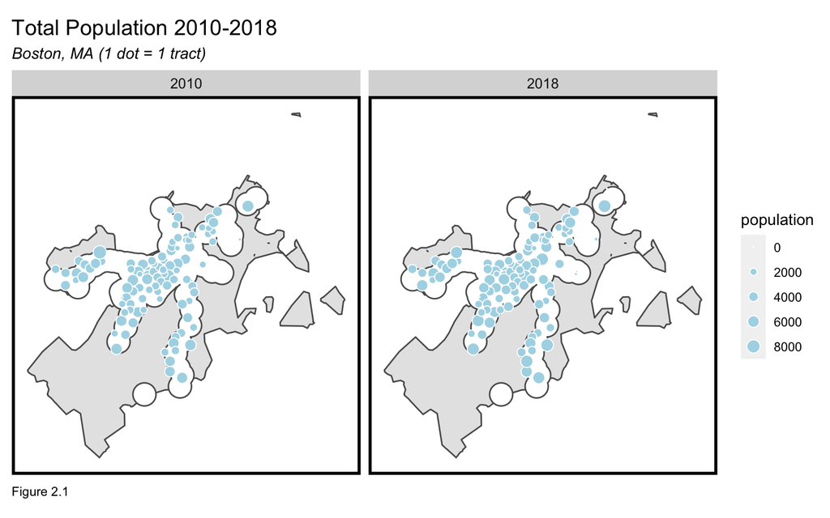

```r
##############################GRADUATED SYMBOL MAPS###############################
# Set up
centectroi10_pop <- st_centroid(selectCentroids10[,1])
centectroi18_pop <- st_centroid(selectCentroids18[,1])
troi_pop <- rbind(selectCentroids10[,1:2], selectCentroids18[,1:2])
oitroi_pop.group <- st_centroid(troi_pop)
centectroi10_re <- st_centroid(selectCentroids10[,2])
centectroi18_re <- st_centroid(selectCentroids18[,2])
troi_rent <- rbind(selectCentroids10[,c(1,3)], selectCentroids18[,c(1,3)])
oitroi_rent.group <- st_centroid(troi_rent)

# Plot Population Map
ggplot() +
  geom_sf(data=st_union(allTracts.group)) +
  geom_sf(data = buffer, fill = "white") +
  geom_sf(data = oitroi_pop.group, aes(size = population), shape = 21, color = "transparent",
          fill = "lightblue", alpha = 1, show.legend = "point") +
  scale_size_continuous(range = c(0.01, 4))+
  facet_wrap(~year)+
  labs(title = "Total Population 2010-2018", subtitle = "Boston, MA (1 dot = 1 tract)", caption="Figure 2.1") +
  mapTheme() +
  theme(plot.title = element_text(size=15))
```

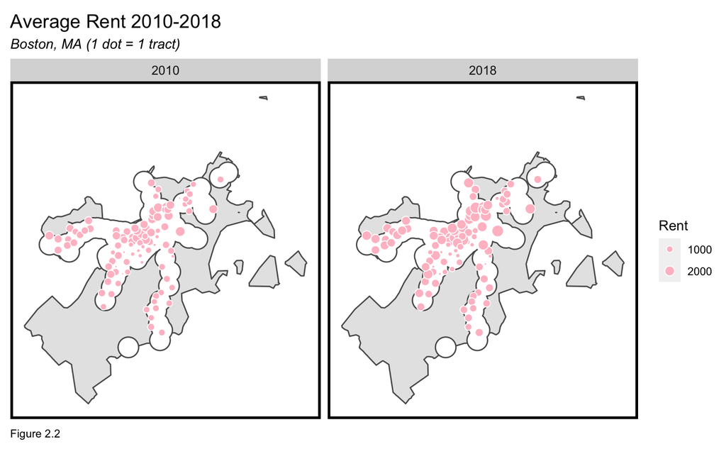

```r
# Plot Rent Map
ggplot() +
  geom_sf(data=st_union(allTractsBos)) +
  geom_sf(data = buffer, fill = "white") +
  geom_sf(data = oitroi_rent.group, aes(size = Rent), shape = 21, color = "transparent",
          fill = "pink", alpha = 1, show.legend = "point") +
  scale_size_continuous(range = c(0.01, 4))+
  facet_wrap(~year)+
  labs(title = "Average Rent 2010-2018", subtitle = "Boston, MA (1 dot = 1 tract)", caption="Figure 2.2") +
  mapTheme() +
  theme(plot.title = element_text(size=15))
```

# 3 How does TOD affect other neighborhood characteristics?

Comparing TOD to non-TOD tracts can clarify the extent to which TOD drives population and rent growth. We also look at share of adults with Bachelor’s degrees (pctBach), median household income (MedHHInc), and share of households without vehicles (pctNoVehicle) to evaluate census tracts’ desirability and walkability.

## 3.1 Population

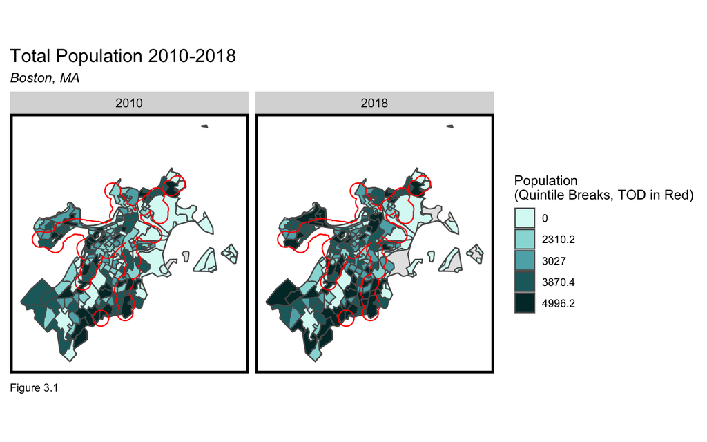

```r
##############################POPULATION SMALL-MULTI MAP##############################
ggplot(allTracts.group)+
  geom_sf(data = st_union(allTractsBos))+
  geom_sf(aes(fill = q5(population))) +
  geom_sf(data = buffer, fill = "transparent", color = "red")+
  scale_fill_manual(values = palette5,
                    labels = qBr(allTracts.group, "population"),
                    name = "Population\n(Quintile Breaks, TOD in Red)") +
  labs(title = "Total Population 2010-2018", subtitle = "Boston, MA", caption="Figure 3.1") +
  facet_wrap(~year)+
  mapTheme() +
  theme(plot.title = element_text(size=15))
```

## 3.2 Bachelor’s Degrees

Neither TOD nor non-TOD tracts experience significant growth in this area, however the share of college educated adults is highest in TOD tracts, with exceptions in the South. This suggests that transit access may have initially attracted this population to TOD tracts, but the growth has slowed. Alternatively, it is possible that this correlation is spurious, and that TOD tracts are attractive for other reasons which appeal to well-educated individuals.

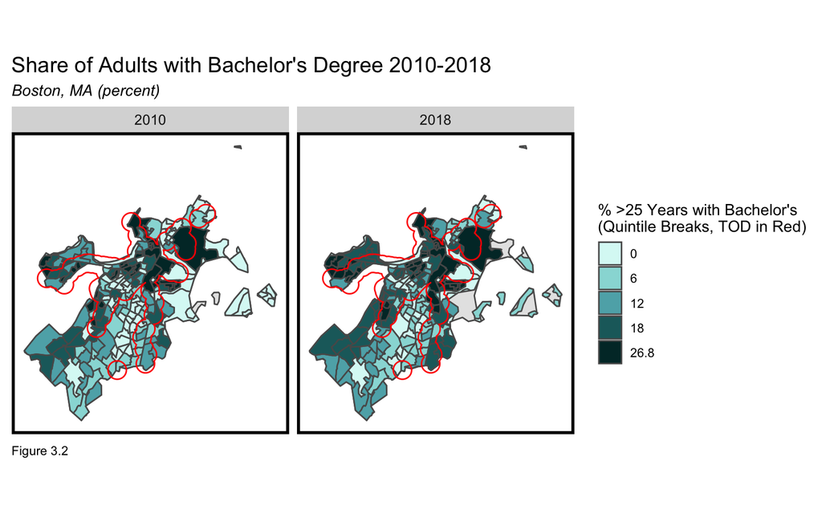

```r
##########################BACHELOR'S SMALL-MULTI MAP############################
ggplot(allTracts.group)+
  geom_sf(data = st_union(allTractsBos))+
  geom_sf(aes(fill = q5(pctBach))) +
  geom_sf(data = buffer, fill = "transparent", color = "red")+
  scale_fill_manual(values = palette5,
                    labels = qBr(allTracts.group %>% mutate(pctBach_100 = pctBach *100), "pctBach_100"),
                    name = "% >25 Years with Bachelor's\n(Quintile Breaks, TOD in Red)") +
  labs(title = "Share of Adults with Bachelor's Degree 2010-2018", subtitle = "Boston, MA (percent)", caption="Figure 3.2") +
  facet_wrap(~year)+
  mapTheme() +
  theme(plot.title = element_text(size=15))
```

## 3.3 Median Household Income

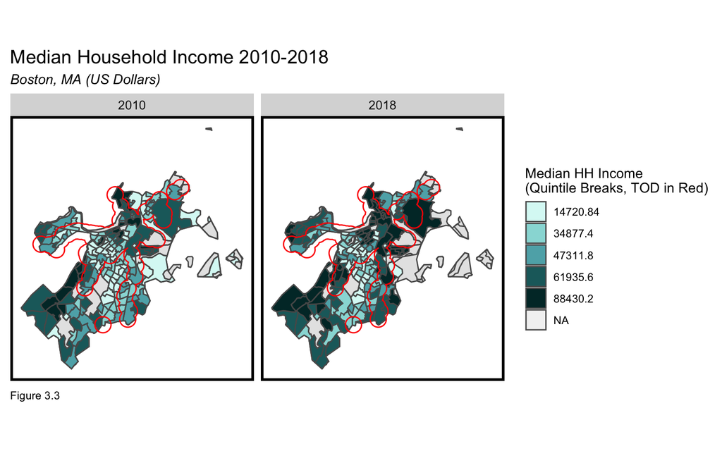

```r
############################INCOME SMALL-MULTI MAP################################
ggplot(allTracts.group)+
  geom_sf(data = st_union(allTractsBos))+
  geom_sf(aes(fill = q5(medHHInc))) +
  geom_sf(data = buffer, fill = "transparent", color = "red")+
  scale_fill_manual(values = palette5,
                    labels = qBr(allTracts.group, "medHHInc"),
                    name = "Median HH Income\n(Quintile Breaks, TOD in Red)") +
  labs(title = "Median Household Income 2010-2018", subtitle = "Boston, MA (US Dollars)", caption="Figure 3.3") +
  facet_wrap(~year)+
  mapTheme() +
  theme(plot.title = element_text(size=15))
```

## 3.4 Households without Vehicles

The most dramatic difference between TOD and non-TOD tracts is the share of households without a vehicle. Many TOD tracts are in the highest pctNoVehicle quintile, while most non-TOD tracts have much lower shares. This suggests that Boston’s transit system makes it viable for non car-owning households to live in TOD tracts.

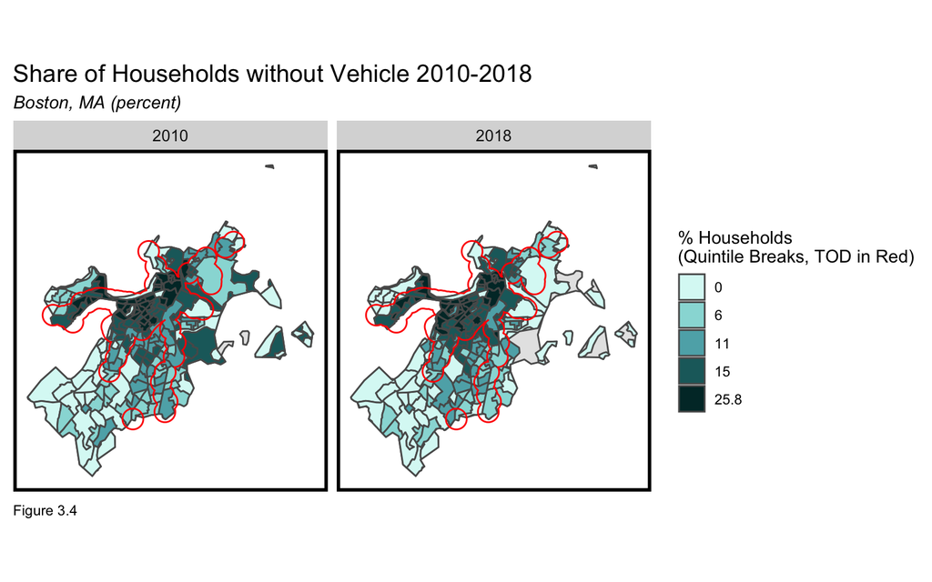

```r
#######################NO VEHICLE SMALL-MULTI MAP###########################
ggplot(allTracts.group)+
  geom_sf(data = st_union(allTractsBos))+
  geom_sf(aes(fill = q5(pctNoVehicle))) +
  geom_sf(data = buffer, fill = "transparent", color = "red")+
  scale_fill_manual(values = palette5,
                    labels = qBr(allTracts.group %>% mutate(pctNoVehicle_100 = pctNoVehicle *100), "pctNoVehicle_100"),
                    name = "% Households\n(Quintile Breaks, TOD in Red)") +
  labs(title = "Share of Households without Vehicle 2010-2018", subtitle = "Boston, MA (percent)", caption="Figure 3.4") +
  facet_wrap(~year)+
  mapTheme() +
  theme(plot.title = element_text(size=15))
```

## 3.5 Summary

```r
#####################NEIGHBORHOOD CHARACTERISTICS TABLE#########################
#Summarize allTracts.group
allTracts.Summary <-
  st_drop_geometry(allTracts.group) %>%
  group_by(year, TOD) %>%
  summarize(Rent = mean(Rent, na.rm = T),
            Population = mean(population, na.rm = T),
            pctBach = mean(pctBach, na.rm = T),
            pctNoVehicle = mean(pctNoVehicle, na.rm = T),
            MedHHInc = mean(medHHInc, na.rm = T))

#Long Form Characteristics Table
allTracts.Summary %>%
  unite(year.TOD, year, TOD, sep = ": ", remove = T) %>%
  gather(Variable, Value, -year.TOD) %>%
  mutate(Value = round(Value, 2)) %>%
  spread(year.TOD, Value) %>%
  kable() %>%
  kable_styling() %>%
  footnote(general_title = "\n",
           general = "Table 3.1")
```

| Variable | 2010: Non-TOD | 2010: TOD | 2018: Non-TOD | 2018: TOD |
| --- | --- | --- | --- | --- |
| MedHHInc | 56146.43 | 52550.29 | 69593.97 | 70423.53 |
| pctBach | 0.12 | 0.18 | 0.15 | 0.20 |
| pctNoVehicle | 0.09 | 0.22 | 0.09 | 0.20 |
| Population | 3238.05 | 3398.96 | 3873.59 | 3668.81 |
| Rent | 964.49 | 1124.75 | 1293.12 | 1475.46 |

Table 3.1

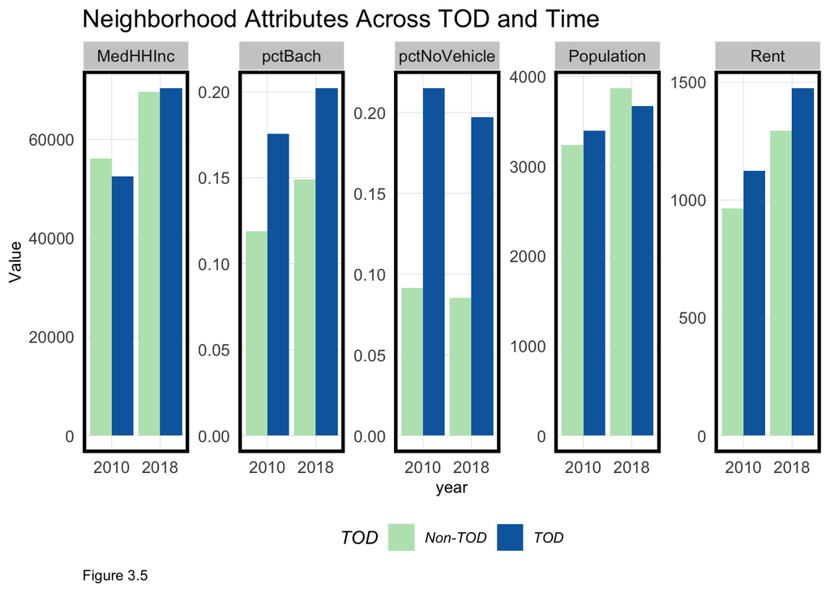

```r
#################NEIGHBORHOOD CHARACTERISTICS GROUP BAR PLOT####################
allTracts.Summary %>%
  gather(Variable, Value, -year, -TOD) %>%
  ggplot(aes(year, Value, fill = TOD)) +
    geom_bar(stat = "identity", position = "dodge") +
    facet_wrap(~Variable, scales = "free", ncol=5) +
    scale_fill_manual(values = c("#bae4bc", "#0868ac")) +
    labs(title = "Neighborhood Attributes Across TOD and Time", caption="Figure 3.5") +
    plotTheme() + theme(legend.position="bottom") +
    theme(plot.title = element_text(size=15))
```

# 4 How does rent vary with distance from transit stops?

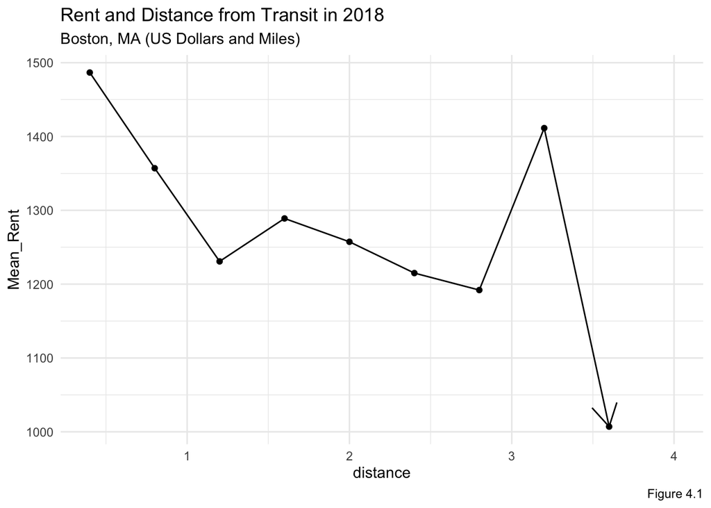

```r
########################RENTxDISTANCE GEOM_LINE PLOT##########################

# 2018
rent_dis18 <- data.frame(
  distance = double(),
  Mean_Rent = double(),
  stringsAsFactors=FALSE
)

for (i in seq(0.4,4, by = 0.4)){

  A <- st_union(st_buffer(bosStations, i*5280)) %>% st_sf()
  a <- st_union(st_buffer(bosStations, (i-0.4)*5280)) %>% st_sf()
  std <- st_difference(A, a)
  b <-
    st_centroid(tracts18)[std,] %>%
    st_drop_geometry() %>%
    left_join(dplyr::select(tracts18, GEOID)) %>%
    st_sf() %>%
    dplyr::select(Rent)
  b$Rent <- as.numeric(b$Rent)
  c <- mean(b[["Rent"]],na.rm=TRUE)
  d <- data.frame(distance=i, Mean_Rent=c, stringsAsFactors=FALSE)
  rent_dis18 <- rbind(rent_dis18, d)
  #  rent_dis10 %>% add_row(distance = i, Mean_Rent = c)
  i <- i + 0.4
}

#2018
ggplot(rent_dis18, aes(x=distance, y=Mean_Rent)) +
  geom_line(arrow = arrow())+
  geom_point()+
  labs(title = "Rent and Distance from Transit in 2018", caption="Figure 4.1", subtitle="Boston, MA (US Dollars and Miles)") +
 theme(plot.title = element_text(size=15))+
  scale_color_brewer(palette="Paired")+theme_minimal()
```

# 5 Are TOD Neighborhoods Safer?

Another proposed benefit of TOD is neighborhood safety. With walkable and transit-rich neighborhoods, there are more “eyes on the street,” a concept of the late urbanist Jane Jacobs who suggested that dense, lively neighborhoods are safer because more residents are on the street. To test this idea, we map cases of a common street crime, robbery. As land value tends to correlate with crime, we map average rent to control for this effect.

TOD tracts seem to have more robberies, particularly downtown. Even when controlling for rent, low-rent non-TOD tracts had fewer robberies than their corresponding TOD tracts. In the higher rent category, non-TOD tracts still have fewer robberies. One factor to note, however, is that many of the high-rent TOD tracts are in the downtown area, which often has the highest crime rates in cities. Still, TOD does not appear to promote public safety in Boston even when controlling for rent.

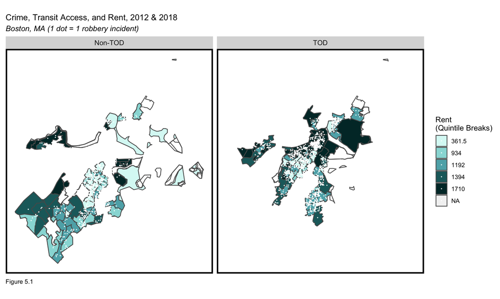

```r
###############################CRIMExRENTxTOD?###############################
# Read crime data
crime12 <- read.csv("/Users/annaduan/Documents/GitHub/TOD-Assignment/Crime12.csv", header = TRUE, sep = ",", quote = "\"",
         dec = ".")
crime18 <- read.csv("/Users/annaduan/Documents/GitHub/TOD-Assignment/Crime18.csv", header = TRUE, sep = ",", quote = "\"",
                       dec = ".")

crime12.sf <- st_as_sf(crime12, coords = c("LON", "LAT"), crs = 4326, agr = "constant") %>%
  st_transform(st_crs(allTracts.group))
crime18.sf <- st_as_sf(crime18, coords = c("LON", "LAT"), crs = 4326, agr = "constant")  %>%
  st_transform(st_crs(allTracts.group))

# Bind crime years
crime.sf <- rbind(crime12.sf, crime18.sf)

# Plot crime and rent for TOD and Non-TOD
ggplot() +
 scale_fill_manual(values = palette5,
                    labels = qBr(allTracts.group, "Rent.inf"),
                    name = "Rent\n(Quintile Breaks)") +
  geom_sf(data=allTracts.group, aes(fill = q5(Rent.inf))) +
  geom_sf(data=crime.sf, show.legend = "point", size= 0.1, color = "white") +
  labs(title="Crime, Transit Access, and Rent, 2012 & 2018", subtitle="Boston, MA (1 dot = 1 robbery incident)", caption="Figure 5.1") +
  facet_wrap(~TOD) +
  theme(plot.title = element_text(size=15)) +
  mapTheme()
```

# 6 Conclusion

In conclusion, TOD tracts have the highest rent, median income, and share of college educated adults in Boston, indicating that they are valued and attract wealthy residents who will generate tax revenue. Additionally, they are appealing and viable living areas for households without vehicles. While it is uncertain how many of these positive characteristics are attributable to TOD and not downtown location or other factors, it appears that Bostonians generally value transit-rich neighborhoods and are willing to pay more for them.

## 6.2 The area south of Downtown has significant potential for growth

While the area below Downtown is non-TOD, it has high population, low income, and low share of adults with bachelor’s degrees. It is likely that, given TOD’s positive effects on neighborhood value, that expansion of public transportation and TOD in this area will yield higher property value and tax revenues. Further, this area has a high share of households without vehicles, which suggests that residents here are already transit-reliant and will benefit from expansion of TOD.

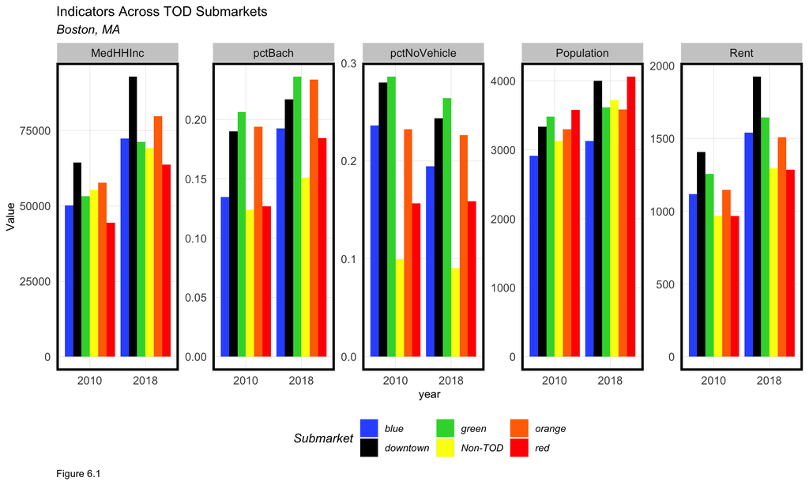

```r
##########################Examining five submarkets ###########################
# Create submarkets for downtown and each line
downtown <-
  st_intersection(
    st_buffer(filter(bosStations, line == "ORANGE/RED"), 2640) %>% st_union()) %>%
  st_sf() %>%
  mutate(Submarket = "downtown")

blue <-
    st_buffer(filter(bosStations, line %in% c("BLUE", "BLUE/ORANGE", "BLUE/GREEN")), 2640) %>% st_union() %>%
  st_sf() %>%
  st_difference(downtown) %>%
  mutate(Submarket = "blue")

orange <-
  st_buffer(filter(bosStations, line %in% c("ORANGE", "BLUE/ORANGE", "GREEN/ORANGE", "ORANGE/RED")), 2640) %>% st_union() %>%
  st_sf() %>%
  st_difference(downtown) %>%
  mutate(Submarket = "orange")

red <-
  st_buffer(filter(bosStations, line %in% c("RED", "ORANGE/RED", "GREEN/RED")), 2640) %>% st_union() %>%
  st_sf() %>%
  st_difference(downtown) %>%
  mutate(Submarket = "red")

green <-
  st_buffer(filter(bosStations, line %in% c("GREEN", "BLUE/GREEN", "GREEN/ORANGE", "GREEN/RED")), 2640) %>% st_union() %>%
  st_sf() %>%
  st_difference(downtown) %>%
  mutate(Submarket = "green")

# Bind 5 submarkets
fiveMarkets <- rbind(red, green, orange, blue, downtown)

# Bind buffers to tracts
allTracts.fiveMarkets <-
  st_join(st_centroid(allTractsBos), fiveMarkets) %>%
  st_drop_geometry() %>%
  left_join(allTractsBos) %>%
  mutate(Submarket = replace_na(Submarket, "Non-TOD")) %>%
  st_sf()

#spread goes long to wide, gather opposite
allTracts.fiveMarkets.Summary <-
  st_drop_geometry(allTracts.fiveMarkets) %>%
  group_by(year, Submarket) %>%
  summarize(Rent = mean(Rent, na.rm = T),
            Population = mean(population, na.rm = T),
            pctBach = mean(pctBach, na.rm = T),
            pctNoVehicle = mean(pctNoVehicle, na.rm = T),
            MedHHInc = mean(medHHInc, na.rm = T))

# Change to long form
allTracts.fiveMarkets.Summary %>%
  unite(year.Submarket, year, Submarket, sep = ": ", remove = T) %>%
  gather(Variable, Value, -year.Submarket) %>%
  mutate(Value = round(Value, 2)) %>%
  spread(year.Submarket, Value)

# Group bar plot comparing submarkets
allTracts.fiveMarkets.Summary %>%
  gather(Variable, Value, -year, -Submarket) %>%
  ggplot(aes(year, Value, fill = Submarket)) +
  geom_bar(stat = "identity", position = "dodge") +
  facet_wrap(~Variable, scales = "free", ncol=5) +
  scale_fill_manual(values = c("#335BFF", "#000000", "#34D539", "#F9FD0A", "#FF7000", "#FF0000", "#CDCDCD")) +
  labs(title = "Indicators Across TOD Submarkets", subtitle="Boston, MA", caption="Figure 6.1") +
    theme(plot.title = element_text(size=15)) +
  plotTheme() + theme(legend.position="bottom")
```

# 7 Data Sources

American Community Survey: https://api.census.gov/data/2010/acs/acs5/variables.html https://api.census.gov/data/2018/acs/acs5/variables.html

Boston Crime: https://data.boston.gov/dataset/crime-incident-reports-july-2012-august-2015-source-legacy-system https://data.boston.gov/dataset/crime-incident-reports-august-2015-to-date-source-new-system

MBTA: https://docs.digital.mass.gov/dataset/massgis-data-trains